# Lecture12 slides

## More SAS with Graphics

### Creating SAS Data Sets from Procedure Output

Sometimes you may want to store the results of a procedure rather than just printing the output. Some procedures have built in options that allow you to store data with an `OUT =` statement. However, with ODS you can save almost any output as a SAS dataset.

The syntax to to do this is as follows:

```
ODS OUTPUT output-object = new-data-set;
```

The ODS Statement is not an option for a SAS DATA or PROC step. The ODS statement executes immediately, so it should be placed after the PROC statement, but before the next PROC, DATA, or RUN statement.

```sas
PROC TABULATE DATA=sashelp.class;
        CLASS Sex;
        VAR Height Weight;
        TABLE Sex, (Height Weight) * MEAN;
ODS OUTPUT Table = group_summaries;
RUN;
```

The SAS System

[output not shown]

```sas
PROC PRINT DATA=group_summaries;
RUN;
```

The SAS System

| Obs | Sex | _TYPE_ | _PAGE_ | _TABLE_ | Height_Mean | Weight_Mean |
| --- | --- | --- | --- | --- | --- | --- |
| 1 | F | 1 | 1 | 1 | 60.5889 | 90.111 |
| 2 | M | 1 | 1 | 1 | 63.9100 | 108.950 |

### Customizing Titles and Footnotes

Titles and Footnotes can be be customized using the following syntax:

```
TITLE options 'text string' options 'text string2'  ... ;

FOOTNOTE options 'text string' options 'text string2'  ... ;
```

This allows use to customize chunks of code with different options.

#### Options

- COLOR (specifies color for text)
- BCOLOR (specifies color for the background of text)
- HEIGHT (specifies the height of the text, can be in PT, IN, or CM)
- JUSTIFY (text justification, LEFT, CENTER, RIGHT)
- FONT (specifies font type)
- BOLD (makes text bold)
- ITALIC (makes text italic)

```sas
TITLE COLOR=BLUE 'Blue ' COLOR =BLACK ' Black ' COLOR = GRAY 'Gray ';
PROC PRINT DATA = sashelp.class;
RUN;
```

BlueBlack Gray

| Obs | Name | Sex | Age | Height | Weight |
| --- | --- | --- | --- | --- | --- |
| 1 | Alfred | M | 14 | 69.0 | 112.5 |
| 2 | Alice | F | 13 | 56.5 | 84.0 |
| 3 | Barbara | F | 13 | 65.3 | 98.0 |
| 4 | Carol | F | 14 | 62.8 | 102.5 |
| 5 | Henry | M | 14 | 63.5 | 102.5 |
| 6 | James | M | 12 | 57.3 | 83.0 |
| 7 | Jane | F | 12 | 59.8 | 84.5 |
| 8 | Janet | F | 15 | 62.5 | 112.5 |
| 9 | Jeffrey | M | 13 | 62.5 | 84.0 |
| 10 | John | M | 12 | 59.0 | 99.5 |
| 11 | Joyce | F | 11 | 51.3 | 50.5 |
| 12 | Judy | F | 14 | 64.3 | 90.0 |
| 13 | Louise | F | 12 | 56.3 | 77.0 |
| 14 | Mary | F | 15 | 66.5 | 112.0 |
| 15 | Philip | M | 16 | 72.0 | 150.0 |
| 16 | Robert | M | 12 | 64.8 | 128.0 |
| 17 | Ronald | M | 15 | 67.0 | 133.0 |
| 18 | Thomas | M | 11 | 57.5 | 85.0 |
| 19 | William | M | 15 | 66.5 | 112.0 |

```sas
TITLE COLOR=BLUE JUSTIFY=LEFT 'Blue '  JUSTIFY=CENTER FONT = ARIAL COLOR =BLACK HEIGHT= 32PT ' Black ' JUSTIFY=RIGHT COLOR = GRAY  'Gray ';
PROC PRINT DATA = sashelp.class;
RUN;
```

Blue Black Gray

| Obs | Name | Sex | Age | Height | Weight |
| --- | --- | --- | --- | --- | --- |
| 1 | Alfred | M | 14 | 69.0 | 112.5 |
| 2 | Alice | F | 13 | 56.5 | 84.0 |
| 3 | Barbara | F | 13 | 65.3 | 98.0 |
| 4 | Carol | F | 14 | 62.8 | 102.5 |
| 5 | Henry | M | 14 | 63.5 | 102.5 |
| 6 | James | M | 12 | 57.3 | 83.0 |
| 7 | Jane | F | 12 | 59.8 | 84.5 |
| 8 | Janet | F | 15 | 62.5 | 112.5 |
| 9 | Jeffrey | M | 13 | 62.5 | 84.0 |
| 10 | John | M | 12 | 59.0 | 99.5 |
| 11 | Joyce | F | 11 | 51.3 | 50.5 |
| 12 | Judy | F | 14 | 64.3 | 90.0 |
| 13 | Louise | F | 12 | 56.3 | 77.0 |
| 14 | Mary | F | 15 | 66.5 | 112.0 |
| 15 | Philip | M | 16 | 72.0 | 150.0 |
| 16 | Robert | M | 12 | 64.8 | 128.0 |
| 17 | Ronald | M | 15 | 67.0 | 133.0 |
| 18 | Thomas | M | 11 | 57.5 | 85.0 |
| 19 | William | M | 15 | 66.5 | 112.0 |

### Style Options

In addition to changing the style template, individual options can also be specified. Using the following syntax (in a PROC PRINT statement).

```
PROC PRINT STYLE (location-list) = {style-attribute = value};
RUN;
```

The location-list options are:

- DATA (all data cells)
- HEADER (the column headers)
- OBS (the data in OBS column)

The style-attributes are:

- BACKGROUND (specifieds the background color, using any valid SAS color)
- FONT_FACE (specifies font type, most devices support Times, Courier, Arial, Helvetica)
- FONT_SIZE (specifies size of the font for text in cells, values 1 - 7)
- FONT_WEIGHT (weight of font: BOLD, MEDIUM, LIGHT)
- FOREGROUND (color of text in the cells)
- JUST (RIGHT, CENTER, LEFT, D for Decimal)

```sas
TITLE;
PROC PRINT DATA= sashelp.class STYLE(DATA) = {FONT_STYLE = ITALIC FONT_WEIGHT = BOLD JUST = D};
RUN;
```

| Obs | Name | Sex | Age | Height | Weight |
| --- | --- | --- | --- | --- | --- |
| 1 | Alfred | M | 14 | 69.0 | 112.5 |
| 2 | Alice | F | 13 | 56.5 | 84.0 |
| 3 | Barbara | F | 13 | 65.3 | 98.0 |
| 4 | Carol | F | 14 | 62.8 | 102.5 |
| 5 | Henry | M | 14 | 63.5 | 102.5 |
| 6 | James | M | 12 | 57.3 | 83.0 |
| 7 | Jane | F | 12 | 59.8 | 84.5 |
| 8 | Janet | F | 15 | 62.5 | 112.5 |
| 9 | Jeffrey | M | 13 | 62.5 | 84.0 |
| 10 | John | M | 12 | 59.0 | 99.5 |
| 11 | Joyce | F | 11 | 51.3 | 50.5 |
| 12 | Judy | F | 14 | 64.3 | 90.0 |
| 13 | Louise | F | 12 | 56.3 | 77.0 |
| 14 | Mary | F | 15 | 66.5 | 112.0 |
| 15 | Philip | M | 16 | 72.0 | 150.0 |
| 16 | Robert | M | 12 | 64.8 | 128.0 |
| 17 | Ronald | M | 15 | 67.0 | 133.0 |
| 18 | Thomas | M | 11 | 57.5 | 85.0 |
| 19 | William | M | 15 | 66.5 | 112.0 |

# Graphics

- Name a few properties of good graphics
- Name a few properties of poor graphics

##### Stand-alone graphs

We have seen some graphs that are produced as part of SAS procedures, but we can also create stand alone graphs. Some options include:

| Category | Types |
| --- | --- |
| X vs. Y | band, bubble, high-low, loess, regression, scatter, series |
| continuous | box, density, histrogram |
| categorical | dot, bar, line |

### PROC SGPLOT

PROC SGPLOT has a lot of similarities to the `ggplot2` package in R. More details and documentation can be found at http://support.sas.com/documentation/cdl/en/grstatproc/62603/HTML/default/viewer.htm#sgplot-ov.htm.

There are four general classes of figures that can be constructed with PROC SGPLOT:

1. Basic Plots (scatter plots, series plots)
2. Fit and confidence plots (loess, regression lines)
3. Distribution plots (box plots, histograms, density estimates)
4. Categorization plots (dot plots, bar charts)

##### PROC SGPLOT syntax

```
PROC SGPLOT DATA=yourdata;
    YAXIS label="labelname" min = 0;
    VBAR variablename;
RUN;
```

VBAR specifies a vertical bar plot and there are many options of different types of figures that can be placed here. We will see several of them in coming slides.

You can also specify characteristics of the axes as well.

#### Bar Graphs

- What is a bar graph?
- When is it useful?
- What are important principles for bar graphs?

```sas
PROC PRINT DATA=sashelp.prdsale;
RUN;
```

| Obs | ACTUAL | PREDICT | COUNTRY | REGION | DIVISION | PRODTYPE | PRODUCT | QUARTER | YEAR | MONTH |
| --- | --- | --- | --- | --- | --- | --- | --- | --- | --- | --- |
| 1 | $925.00 | $850.00 | CANADA | EAST | EDUCATION | FURNITURE | SOFA | 1 | 1993 | Jan |
| 2 | $999.00 | $297.00 | CANADA | EAST | EDUCATION | FURNITURE | SOFA | 1 | 1993 | Feb |
| 3 | $608.00 | $846.00 | CANADA | EAST | EDUCATION | FURNITURE | SOFA | 1 | 1993 | Mar |
| 4 | $642.00 | $533.00 | CANADA | EAST | EDUCATION | FURNITURE | SOFA | 2 | 1993 | Apr |
| 5 | $656.00 | $646.00 | CANADA | EAST | EDUCATION | FURNITURE | SOFA | 2 | 1993 | May |
| 6 | $948.00 | $486.00 | CANADA | EAST | EDUCATION | FURNITURE | SOFA | 2 | 1993 | Jun |
| 7 | $612.00 | $717.00 | CANADA | EAST | EDUCATION | FURNITURE | SOFA | 3 | 1993 | Jul |
| 8 | $114.00 | $564.00 | CANADA | EAST | EDUCATION | FURNITURE | SOFA | 3 | 1993 | Aug |
| 9 | $685.00 | $230.00 | CANADA | EAST | EDUCATION | FURNITURE | SOFA | 3 | 1993 | Sep |
| 10 | $657.00 | $494.00 | CANADA | EAST | EDUCATION | FURNITURE | SOFA | 4 | 1993 | Oct |
| 11 | $608.00 | $903.00 | CANADA | EAST | EDUCATION | FURNITURE | SOFA | 4 | 1993 | Nov |
| 12 | $353.00 | $266.00 | CANADA | EAST | EDUCATION | FURNITURE | SOFA | 4 | 1993 | Dec |
| 13 | $107.00 | $190.00 | CANADA | EAST | EDUCATION | FURNITURE | SOFA | 1 | 1994 | Jan |
| 14 | $354.00 | $139.00 | CANADA | EAST | EDUCATION | FURNITURE | SOFA | 1 | 1994 | Feb |
| 15 | $101.00 | $217.00 | CANADA | EAST | EDUCATION | FURNITURE | SOFA | 1 | 1994 | Mar |
| 16 | $553.00 | $560.00 | CANADA | EAST | EDUCATION | FURNITURE | SOFA | 2 | 1994 | Apr |
| 17 | $877.00 | $148.00 | CANADA | EAST | EDUCATION | FURNITURE | SOFA | 2 | 1994 | May |
| 18 | $431.00 | $762.00 | CANADA | EAST | EDUCATION | FURNITURE | SOFA | 2 | 1994 | Jun |
| 19 | $511.00 | $457.00 | CANADA | EAST | EDUCATION | FURNITURE | SOFA | 3 | 1994 | Jul |
| 20 | $157.00 | $532.00 | CANADA | EAST | EDUCATION | FURNITURE | SOFA | 3 | 1994 | Aug |
| 21 | $520.00 | $629.00 | CANADA | EAST | EDUCATION | FURNITURE | SOFA | 3 | 1994 | Sep |
| 22 | $114.00 | $491.00 | CANADA | EAST | EDUCATION | FURNITURE | SOFA | 4 | 1994 | Oct |
| 23 | $277.00 | $0.00 | CANADA | EAST | EDUCATION | FURNITURE | SOFA | 4 | 1994 | Nov |
| 24 | $561.00 | $979.00 | CANADA | EAST | EDUCATION | FURNITURE | SOFA | 4 | 1994 | Dec |
| 25 | $220.00 | $585.00 | CANADA | EAST | EDUCATION | FURNITURE | BED | 1 | 1993 | Jan |
| 26 | $444.00 | $267.00 | CANADA | EAST | EDUCATION | FURNITURE | BED | 1 | 1993 | Feb |
| 27 | $178.00 | $487.00 | CANADA | EAST | EDUCATION | FURNITURE | BED | 1 | 1993 | Mar |
| 28 | $756.00 | $764.00 | CANADA | EAST | EDUCATION | FURNITURE | BED | 2 | 1993 | Apr |
| 29 | $329.00 | $312.00 | CANADA | EAST | EDUCATION | FURNITURE | BED | 2 | 1993 | May |
| 30 | $910.00 | $531.00 | CANADA | EAST | EDUCATION | FURNITURE | BED | 2 | 1993 | Jun |

[output cut: 1410 more lines]

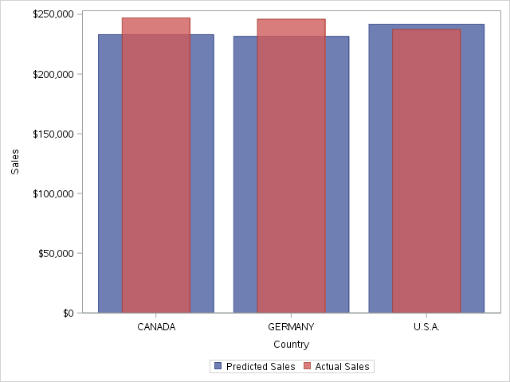

```sas
proc sgplot data=sashelp.prdsale;
  yaxis label="Sales" min=0;
  vbar country / response=predict;
  vbar country / response=actual
                  barwidth=0.5
                  transparency=0.2;
run;
```

## Bar Graph Exercise:

- Use the bikes dataset to create a bar graph.
- What story does your figure tell?

```sas
libname STAT408 '/folders/myfolders/';
```

[output not shown]

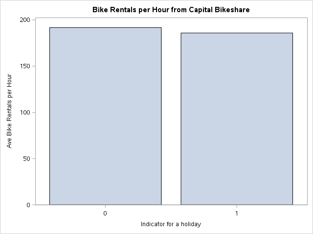

```sas
Proc SGPLOT Data= STAT408.bikes;
	vbar holiday/ response=count stat=MEAN;
	yaxis label="Ave Bike Rentals per Hour";
	xaxis label='Indicator for a holiday';
	title 'Bike Rentals per Hour from Capital Bikeshare';
RUN;
```

#### Histograms and Density Curves

- What is a density curve?
- How is it different than a histogram?

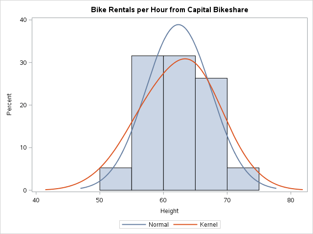

```sas
proc sgplot data=sashelp.class;
  histogram height;
  density height;
  density height / type=kernel;
run;
```

## Exercise: Histogram and Density Curves

- Use one of the datasets in the STAT408 folder to create a histogram and density plot.
- Note this will need to be a continuous variable.
- What story does your graphic tell?

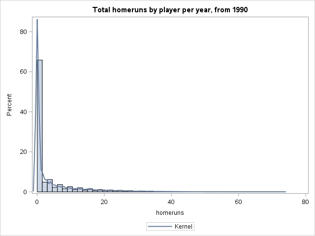

```sas
Data current_batting;
	SET STAT408.batting;
	IF YEAR > 1990 AND AB NE .;
RUN;

PROC SGPLOT DATA= CURRENT_BATTING;
	histogram HR;
	density HR / type= kernel;
	title 'Total homeruns by player per year, from 1990';
	xaxis label='homeruns';
RUN;
```

#### Box Plots

- What type of data is typically displayed with a box plot?
- Sketch a box plot.
- Label key components on your figure.

```sas
Proc Print DATA=sashelp.cars;
    title;
    RUN;
```

| Obs | Make | Model | Type | Origin | DriveTrain | MSRP | Invoice | EngineSize | Cylinders | Horsepower | MPG_City | MPG_Highway | Weight | Wheelbase | Length |
| --- | --- | --- | --- | --- | --- | --- | --- | --- | --- | --- | --- | --- | --- | --- | --- |
| 1 | Acura | MDX | SUV | Asia | All | $36,945 | $33,337 | 3.5 | 6 | 265 | 17 | 23 | 4451 | 106 | 189 |
| 2 | Acura | RSX Type S 2dr | Sedan | Asia | Front | $23,820 | $21,761 | 2.0 | 4 | 200 | 24 | 31 | 2778 | 101 | 172 |
| 3 | Acura | TSX 4dr | Sedan | Asia | Front | $26,990 | $24,647 | 2.4 | 4 | 200 | 22 | 29 | 3230 | 105 | 183 |
| 4 | Acura | TL 4dr | Sedan | Asia | Front | $33,195 | $30,299 | 3.2 | 6 | 270 | 20 | 28 | 3575 | 108 | 186 |
| 5 | Acura | 3.5 RL 4dr | Sedan | Asia | Front | $43,755 | $39,014 | 3.5 | 6 | 225 | 18 | 24 | 3880 | 115 | 197 |
| 6 | Acura | 3.5 RL w/Navigation 4dr | Sedan | Asia | Front | $46,100 | $41,100 | 3.5 | 6 | 225 | 18 | 24 | 3893 | 115 | 197 |
| 7 | Acura | NSX coupe 2dr manual S | Sports | Asia | Rear | $89,765 | $79,978 | 3.2 | 6 | 290 | 17 | 24 | 3153 | 100 | 174 |
| 8 | Audi | A4 1.8T 4dr | Sedan | Europe | Front | $25,940 | $23,508 | 1.8 | 4 | 170 | 22 | 31 | 3252 | 104 | 179 |
| 9 | Audi | A41.8T convertible 2dr | Sedan | Europe | Front | $35,940 | $32,506 | 1.8 | 4 | 170 | 23 | 30 | 3638 | 105 | 180 |
| 10 | Audi | A4 3.0 4dr | Sedan | Europe | Front | $31,840 | $28,846 | 3.0 | 6 | 220 | 20 | 28 | 3462 | 104 | 179 |
| 11 | Audi | A4 3.0 Quattro 4dr manual | Sedan | Europe | All | $33,430 | $30,366 | 3.0 | 6 | 220 | 17 | 26 | 3583 | 104 | 179 |
| 12 | Audi | A4 3.0 Quattro 4dr auto | Sedan | Europe | All | $34,480 | $31,388 | 3.0 | 6 | 220 | 18 | 25 | 3627 | 104 | 179 |
| 13 | Audi | A6 3.0 4dr | Sedan | Europe | Front | $36,640 | $33,129 | 3.0 | 6 | 220 | 20 | 27 | 3561 | 109 | 192 |
| 14 | Audi | A6 3.0 Quattro 4dr | Sedan | Europe | All | $39,640 | $35,992 | 3.0 | 6 | 220 | 18 | 25 | 3880 | 109 | 192 |
| 15 | Audi | A4 3.0 convertible 2dr | Sedan | Europe | Front | $42,490 | $38,325 | 3.0 | 6 | 220 | 20 | 27 | 3814 | 105 | 180 |
| 16 | Audi | A4 3.0 Quattro convertible 2dr | Sedan | Europe | All | $44,240 | $40,075 | 3.0 | 6 | 220 | 18 | 25 | 4013 | 105 | 180 |
| 17 | Audi | A6 2.7 Turbo Quattro 4dr | Sedan | Europe | All | $42,840 | $38,840 | 2.7 | 6 | 250 | 18 | 25 | 3836 | 109 | 192 |
| 18 | Audi | A6 4.2 Quattro 4dr | Sedan | Europe | All | $49,690 | $44,936 | 4.2 | 8 | 300 | 17 | 24 | 4024 | 109 | 193 |
| 19 | Audi | A8 L Quattro 4dr | Sedan | Europe | All | $69,190 | $64,740 | 4.2 | 8 | 330 | 17 | 24 | 4399 | 121 | 204 |
| 20 | Audi | S4 Quattro 4dr | Sedan | Europe | All | $48,040 | $43,556 | 4.2 | 8 | 340 | 14 | 20 | 3825 | 104 | 179 |
| 21 | Audi | RS 6 4dr | Sports | Europe | Front | $84,600 | $76,417 | 4.2 | 8 | 450 | 15 | 22 | 4024 | 109 | 191 |
| 22 | Audi | TT 1.8 convertible 2dr (coupe) | Sports | Europe | Front | $35,940 | $32,512 | 1.8 | 4 | 180 | 20 | 28 | 3131 | 95 | 159 |
| 23 | Audi | TT 1.8 Quattro 2dr (convertible) | Sports | Europe | All | $37,390 | $33,891 | 1.8 | 4 | 225 | 20 | 28 | 2921 | 96 | 159 |
| 24 | Audi | TT 3.2 coupe 2dr (convertible) | Sports | Europe | All | $40,590 | $36,739 | 3.2 | 6 | 250 | 21 | 29 | 3351 | 96 | 159 |
| 25 | Audi | A6 3.0 Avant Quattro | Wagon | Europe | All | $40,840 | $37,060 | 3.0 | 6 | 220 | 18 | 25 | 4035 | 109 | 192 |
| 26 | Audi | S4 Avant Quattro | Wagon | Europe | All | $49,090 | $44,446 | 4.2 | 8 | 340 | 15 | 21 | 3936 | 104 | 179 |
| 27 | BMW | X3 3.0i | SUV | Europe | All | $37,000 | $33,873 | 3.0 | 6 | 225 | 16 | 23 | 4023 | 110 | 180 |
| 28 | BMW | X5 4.4i | SUV | Europe | All | $52,195 | $47,720 | 4.4 | 8 | 325 | 16 | 22 | 4824 | 111 | 184 |
| 29 | BMW | 325i 4dr | Sedan | Europe | Rear | $28,495 | $26,155 | 2.5 | 6 | 184 | 20 | 29 | 3219 | 107 | 176 |
| 30 | BMW | 325Ci 2dr | Sedan | Europe | Rear | $30,795 | $28,245 | 2.5 | 6 | 184 | 20 | 29 | 3197 | 107 | 177 |

[output cut: 398 more lines]

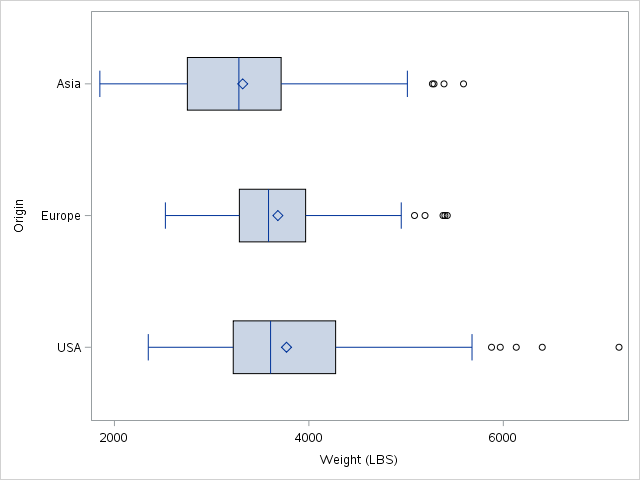

```sas
proc sgplot data=sashelp.cars;
  hbox weight / category=origin;
  title ;
run;
```

#### Scatter plots

- What type of data is typically displayed with a scatter plot?
- Sketch a scatter plot between house square footage and house closing price.

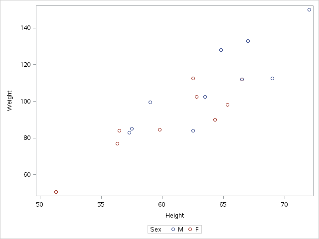

```sas
proc sgplot data=sashelp.class;
  scatter x=height y=weight / group=sex;
run;
```

##### Adding Curves to scatter plots

- Name two ways to add a curve to a scatter plot

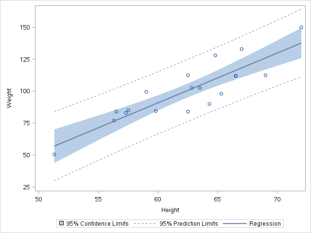

```sas
proc sgplot data=sashelp.class;
  reg x=height y=weight / CLM CLI;
run;
```

## Exercise: Scatterplots

- using one of our datasets create a scatterplot
- what story does this figure tell?

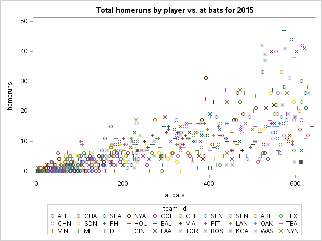

```sas
Data batting2015;
	SET STAT408.batting;
	IF YEAR = 2015 AND AB > 0;
RUN;
PROC SGPLOT DATA= batting2015;
	scatter Y=HR X=ab/ group=team_id;
	title 'Total homeruns by player vs. at bats for 2015';
	yaxis label='homeruns';
	xaxis Label = 'at bats';
RUN;
```

#### Time Series plots

- How are time series plots similar and different from scatter plots?

```sas
PROC PRINT data=sashelp.stocks
  (where=(date >= "01jan2000"d and stock = "IBM"));
RUN;
```

| Obs | Stock | Date | Open | High | Low | Close | Volume | AdjClose |
| --- | --- | --- | --- | --- | --- | --- | --- | --- |
| 1 | IBM | 01DEC05 | $89.15 | $89.92 | $81.56 | $82.20 | 5,976,252 | $81.37 |
| 2 | IBM | 01NOV05 | $81.85 | $89.94 | $80.64 | $88.90 | 5,556,471 | $88.01 |
| 3 | IBM | 03OCT05 | $80.22 | $84.60 | $78.70 | $81.88 | 7,019,666 | $80.86 |
| 4 | IBM | 01SEP05 | $80.16 | $82.11 | $76.93 | $80.22 | 5,772,280 | $79.22 |
| 5 | IBM | 01AUG05 | $83.00 | $84.20 | $79.87 | $80.62 | 4,801,386 | $79.62 |
| 6 | IBM | 01JUL05 | $74.30 | $85.11 | $74.16 | $83.46 | 8,056,590 | $82.23 |
| 7 | IBM | 01JUN05 | $75.57 | $77.73 | $73.45 | $74.20 | 6,439,536 | $73.10 |
| 8 | IBM | 02MAY05 | $76.88 | $78.11 | $72.50 | $75.55 | 6,896,904 | $74.43 |
| 9 | IBM | 01APR05 | $91.49 | $91.76 | $71.85 | $76.38 | 10,709,200 | $75.05 |
| 10 | IBM | 01MAR05 | $92.64 | $93.73 | $89.09 | $91.38 | 5,025,627 | $89.79 |
| 11 | IBM | 01FEB05 | $93.67 | $94.97 | $91.55 | $92.58 | 4,455,657 | $90.97 |
| 12 | IBM | 03JAN05 | $98.97 | $99.10 | $91.44 | $93.42 | 5,960,945 | $91.62 |
| 13 | IBM | 01DEC04 | $94.50 | $99.00 | $94.47 | $98.58 | 5,043,800 | $96.68 |
| 14 | IBM | 01NOV04 | $89.33 | $96.63 | $89.23 | $94.24 | 5,754,876 | $92.42 |
| 15 | IBM | 01OCT04 | $85.95 | $90.27 | $84.29 | $89.75 | 5,839,742 | $87.85 |
| 16 | IBM | 01SEP04 | $84.05 | $87.28 | $83.24 | $85.74 | 4,719,252 | $83.93 |
| 17 | IBM | 02AUG04 | $86.87 | $87.39 | $81.90 | $84.69 | 4,298,600 | $82.90 |
| 18 | IBM | 01JUL04 | $88.28 | $88.44 | $83.42 | $87.07 | 5,929,023 | $85.05 |
| 19 | IBM | 01JUN04 | $88.00 | $91.21 | $87.30 | $88.15 | 4,604,409 | $86.10 |
| 20 | IBM | 03MAY04 | $88.13 | $89.75 | $85.12 | $88.59 | 5,395,555 | $86.53 |
| 21 | IBM | 01APR04 | $91.67 | $94.55 | $88.01 | $88.17 | 5,507,214 | $85.95 |
| 22 | IBM | 01MAR04 | $96.50 | $97.60 | $90.28 | $91.84 | 5,612,921 | $89.53 |
| 23 | IBM | 02FEB04 | $99.15 | $100.43 | $95.20 | $96.50 | 5,392,468 | $94.07 |
| 24 | IBM | 02JAN04 | $92.86 | $99.85 | $89.01 | $99.23 | 7,275,305 | $96.57 |
| 25 | IBM | 01DEC03 | $90.90 | $94.12 | $90.03 | $92.68 | 5,492,295 | $90.20 |
| 26 | IBM | 03NOV03 | $89.90 | $91.48 | $87.72 | $90.54 | 5,271,663 | $88.12 |
| 27 | IBM | 01OCT03 | $88.75 | $94.54 | $87.53 | $89.48 | 6,999,200 | $86.93 |
| 28 | IBM | 02SEP03 | $82.40 | $93.47 | $82.30 | $88.33 | 8,523,800 | $85.81 |
| 29 | IBM | 01AUG03 | $81.15 | $84.72 | $78.73 | $82.01 | 5,624,661 | $79.67 |
| 30 | IBM | 01JUL03 | $81.40 | $87.03 | $80.58 | $81.25 | 7,362,086 | $78.77 |
| 31 | IBM | 02JUN03 | $89.00 | $89.08 | $79.81 | $82.50 | 9,163,771 | $79.98 |
| 32 | IBM | 01MAY03 | $85.30 | $90.40 | $84.45 | $88.04 | 7,415,819 | $85.36 |
| 33 | IBM | 01APR03 | $78.50 | $86.49 | $78.12 | $84.90 | 8,872,342 | $82.16 |
| 34 | IBM | 03MAR03 | $78.90 | $84.90 | $73.17 | $78.43 | 9,624,114 | $75.90 |
| 35 | IBM | 03FEB03 | $78.20 | $80.05 | $74.31 | $77.95 | 8,013,573 | $75.44 |
| 36 | IBM | 02JAN03 | $78.80 | $88.95 | $77.02 | $78.20 | 9,698,933 | $75.53 |
| 37 | IBM | 02DEC02 | $88.60 | $89.46 | $75.60 | $77.50 | 7,592,138 | $74.85 |
| 38 | IBM | 01NOV02 | $78.90 | $88.11 | $76.70 | $86.92 | 9,370,940 | $83.95 |
| 39 | IBM | 01OCT02 | $59.20 | $79.79 | $54.01 | $78.94 | 12,847,417 | $76.11 |
| 40 | IBM | 03SEP02 | $74.20 | $77.50 | $57.99 | $58.31 | 9,934,225 | $56.22 |
| 41 | IBM | 01AUG02 | $70.40 | $82.85 | $65.85 | $75.38 | 7,787,490 | $72.67 |
| 42 | IBM | 01JUL02 | $72.01 | $74.20 | $65.70 | $70.40 | 11,771,613 | $67.72 |
| 43 | IBM | 03JUN02 | $80.75 | $80.95 | $66.10 | $72.00 | 10,096,315 | $69.26 |
| 44 | IBM | 01MAY02 | $83.85 | $86.49 | $75.92 | $80.45 | 8,084,754 | $77.39 |
| 45 | IBM | 01APR02 | $104.00 | $104.00 | $83.34 | $83.76 | 11,608,509 | $80.42 |
| 46 | IBM | 01MAR02 | $98.60 | $108.85 | $98.50 | $104.00 | 7,830,800 | $99.85 |
| 47 | IBM | 01FEB02 | $107.64 | $109.30 | $95.76 | $98.12 | 9,487,368 | $94.20 |
| 48 | IBM | 02JAN02 | $120.60 | $126.39 | $101.00 | $107.89 | 9,687,614 | $103.45 |
| 49 | IBM | 03DEC01 | $114.80 | $124.70 | $113.21 | $120.96 | 6,845,325 | $115.98 |
| 50 | IBM | 01NOV01 | $107.25 | $117.00 | $106.90 | $115.59 | 6,701,623 | $110.83 |
| 51 | IBM | 01OCT01 | $91.72 | $112.10 | $91.34 | $108.07 | 10,066,486 | $103.49 |
| 52 | IBM | 04SEP01 | $100.15 | $103.13 | $87.49 | $91.72 | 13,359,313 | $87.83 |
| 53 | IBM | 01AUG01 | $105.35 | $110.09 | $98.86 | $99.95 | 6,588,178 | $95.71 |
| 54 | IBM | 02JUL01 | $113.50 | $115.40 | $101.56 | $105.21 | 7,934,257 | $100.62 |
| 55 | IBM | 01JUN01 | $112.50 | $119.00 | $111.10 | $113.50 | 7,257,480 | $108.55 |
| 56 | IBM | 01MAY01 | $115.85 | $119.90 | $110.96 | $111.80 | 7,549,104 | $106.92 |
| 57 | IBM | 02APR01 | $97.45 | $118.05 | $90.05 | $115.14 | 11,678,405 | $109.98 |
| 58 | IBM | 01MAR01 | $99.30 | $108.40 | $87.65 | $96.18 | 12,000,513 | $91.87 |
| 59 | IBM | 01FEB01 | $112.40 | $118.64 | $99.10 | $99.90 | 8,861,689 | $95.43 |
| 60 | IBM | 02JAN01 | $84.50 | $116.75 | $83.75 | $112.00 | 9,872,776 | $106.86 |
| 61 | IBM | 01DEC00 | $94.44 | $104.75 | $80.06 | $85.00 | 8,739,385 | $81.10 |
| 62 | IBM | 01NOV00 | $98.44 | $104.37 | $91.62 | $93.50 | 6,720,342 | $89.21 |
| 63 | IBM | 02OCT00 | $112.62 | $119.62 | $86.94 | $98.50 | 10,658,263 | $93.86 |
| 64 | IBM | 01SEP00 | $133.06 | $134.94 | $110.25 | $112.62 | 5,855,495 | $107.32 |
| 65 | IBM | 01AUG00 | $112.00 | $134.25 | $110.25 | $132.02 | 5,545,682 | $125.80 |
| 66 | IBM | 03JUL00 | $108.75 | $117.81 | $100.00 | $112.25 | 7,764,845 | $106.84 |
| 67 | IBM | 01JUN00 | $107.56 | $122.31 | $105.50 | $109.56 | 6,586,172 | $104.28 |
| 68 | IBM | 01MAY00 | $112.50 | $113.62 | $102.00 | $107.31 | 5,800,554 | $102.14 |
| 69 | IBM | 03APR00 | $120.00 | $128.00 | $101.25 | $111.50 | 9,127,221 | $106.00 |
| 70 | IBM | 01MAR00 | $102.00 | $128.25 | $99.50 | $118.37 | 8,800,373 | $112.53 |
| 71 | IBM | 01FEB00 | $112.37 | $119.75 | $100.94 | $102.75 | 7,203,815 | $97.68 |
| 72 | IBM | 03JAN00 | $112.44 | $124.75 | $109.62 | $112.25 | 9,076,280 | $106.60 |

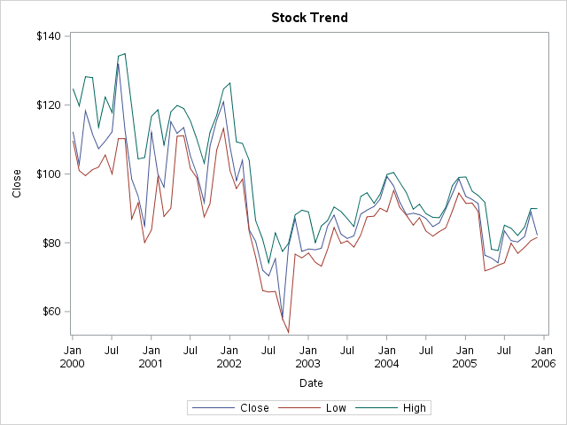

```sas
proc sgplot data=sashelp.stocks
  (where=(date >= "01jan2000"d and stock = "IBM"));
  title "Stock Trend";
  series x=date y=close;
  series x=date y=low;
  series x=date y=high;
run;
```

#### Controlling Features on SAS SGPLOT

- What might we want to adjust with some of these graphics?
- Axes
- Titles
- Reference lines
- Legends
- Insets (text annotation)
- Point types
- Line attributes

##### Axes

Specify either XAXIS or YAXIS. Full details are available here: http://support.sas.com/documentation/cdl/en/grstatproc/62603/HTML/default/viewer.htm#xaxis-stmt.htm

```
PROC SGPLOT DATA=yourdata;
    XAXIS options;
```

options include:

- GRID (creates tick mark on the axis)
- LABEL = 'textstring'
- VALUES = (value-list) specifies value for tick marks. Values must be in parenthesis and can be either formatted as a list (0 5 10 15 20) or as a range (0 TO 20 BY 5).

##### Reference Lines

Reference lines are horizontal or vertical lines on a graph.

```
PROC SGPLOT DATA = yourdata;
    REFLINE values / options;
```

The values can be specified as a list or range. The options include:

- AXIS = axis
- LABEL = (label-list) Specifies one or more text strings to be used as labels
- TRANSPARENCY = n, where n is between 0 and 1.

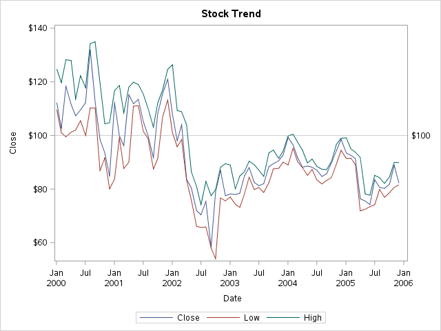

```sas
proc sgplot data=sashelp.stocks
  (where=(date >= "01jan2000"d and stock = "IBM"));
  title "Stock Trend";
  series x=date y=close;
  series x=date y=low;
  series x=date y=high;
  REFLINE 100/ AXIS = Y LABEL= ('$100') TRANSPARENCY=.5;
run;
```

#### Legends

PROC SGPLOT procedures generate legends automatically, which can be good or bad depending on the situation. To change legends the following statement should be added to a SGPLOT procedures:

```
KEYLEGEND / options;
```

options include:

- ACROSS = n (number of columns in the legend)
- DOWN = n (number of rows in the legend)
- LOCATION = value (location for legend, either INSIDE or OUTSIDE, the default)
- NOBORDER (removes the border)
- POSITION = value (specifies the position of the legend, TOP, TOPLEFT, TOPRIGHT, BOTTOM, BOTTOMLEFT, BOTTOMRIGHT, LEFT, RIGHT

##### Removing Legend

```
PROC SGPLOT DATA=yourdata NOAUTOLEGEND;
```

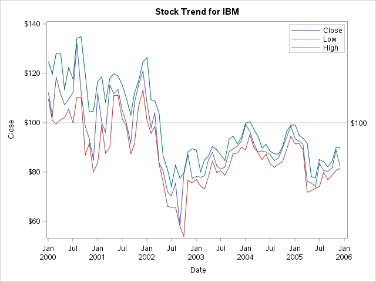

```sas
proc sgplot data=sashelp.stocks
  (where=(date >= "01jan2000"d and stock = "IBM"));
  title "Stock Trend for IBM";
  series x=date y=close;
  series x=date y=low;
  series x=date y=high;
  REFLINE 100/ AXIS = Y LABEL= ('$100') TRANSPARENCY=.5;
  KEYLEGEND/ DOWN=3 POSITION=TOPRIGHT LOCATION=INSIDE;
run;
```

#### INSETS (Text Annotation)

Insets can be added to the plot using the following syntax:

```
INSET 'text-string1' 'text-string2' / options;
```

Options include:

- BORDER (adds a border)
- POSITION = VALUE (TOP, TOPLEFT, TOPRIGHT, BOTTOM, BOTTOMLEFT, BOTTOMRIGHT, LEFT, RIGHT)

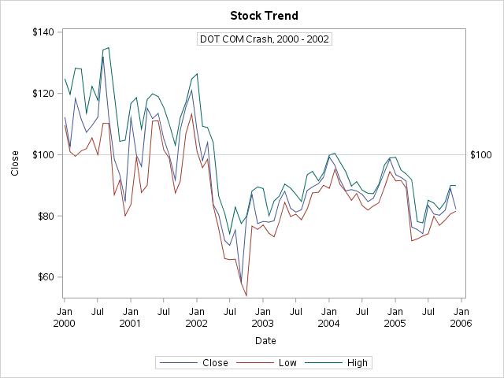

```sas
proc sgplot data=sashelp.stocks
  (where=(date >= "01jan2000"d and stock = "IBM"));
  title "Stock Trend";
  series x=date y=close;
  series x=date y=low;
  series x=date y=high;
  REFLINE 100/ AXIS = Y LABEL= ('$100') TRANSPARENCY=.5;
  INSET 'DOT COM Crash, 2000 - 2002' / POSITION=TOP BORDER;
run;
```

#### Additional Graph Attributes

There are other options that can be manipulated in SGPLOT by placing options ofter the the basic plot statement (and a slash). Some examples are shown below:

- LABELATTRS = (attribute = value) specifies the appearance of the axis labels, options include COLOR, SIZE, STYLE and WEIGHT.
- LINEATTRS = (attribute = value) appearance of line, options include COLOR, PATTERN, THICKNESS
- MARKERATTRS = (attribute = value) appearance of maker, options include COLOR, SIZE, SYMBOL
- VALUEATTRS = (attribute = value) appearance of axis tick labels, options include COLOR, SIZE, STYLE, WEIGHT.

The options for the attributes are:

- COLOR = (RGB notation as hexideximal #FF0000 (red) or named values RED
- SIZE = (numbers with units CM, IN, MM, PCT, PT, or PX
- STYLE = (ITALIC or NORMAL)
- WEIGHT = (BOLD or NORMAL
- PATTERN = (SOLID, DASH, SHORTDASH, LONGDASH, DOT, DASHDASHDOT, DASHDOTDOT)
- THICKNESS = (numbers with units CM, IN, MM, PCT, PT, or PX
- SYMBOL = (CIRCLE, CIRCLEFILLED, DIAMOND, DIAMONDFILLED,PLUS,SQUARE, SQUAREFILLED, STAR, TRIANGLE)

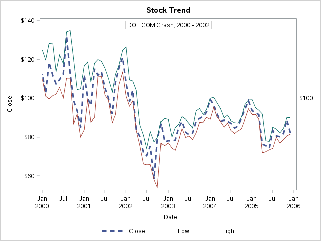

```sas
proc sgplot data=sashelp.stocks
  (where=(date >= "01jan2000"d and stock = "IBM"));
  title "Stock Trend";
  series x=date y=close / LINEATTRS = (THICKNESS = 1MM PATTERN = DASH);
  series x=date y=low;
  series x=date y=high;
  REFLINE 100/ AXIS = Y LABEL= ('$100') TRANSPARENCY=.5;
  INSET 'DOT COM Crash, 2000 - 2002' / POSITION=TOP BORDER;
run;
```

### Exercise: Annotation

- Add annotation and updated labels/title to one of your previous figures.

### Paneled Graphics

The SGPANEL procedure can be used to create graphics within a panel. The general structure follows as:

```
PROC SGPANEL DATA=yourdata;
    PANELBY variable;
    plottype;
```

The plot types are similar to SGPLOT:

- HBAR
- VBAR
- HISTOGRAM
- LOESS
- REG
- SCATTER
- SERIES

Complete details can be found at: http://support.sas.com/documentation/cdl/en/grstatproc/69716/HTML/default/viewer.htm#p17wwoehcyc6mxn1hpcgxy8ixw6w.htm

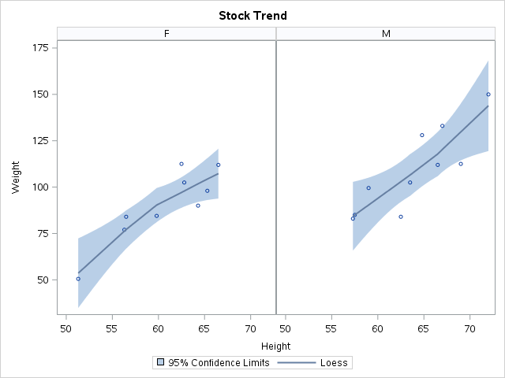

```sas
proc sgpanel data=sashelp.class;
    panelby sex / novarname;
    loess x=height y=weight / clm;
run;
```

### More on Graphics from SAS PROC steps

Stock Trend

The REG Procedure

Model: MODEL1

Dependent Variable: Weight

| Number of Observations Read | 19 |
| --- | --- |
| Number of Observations Used | 19 |

| Analysis of Variance Source | Analysis of Variance DF | Analysis of Variance Sum of Squares | Analysis of Variance Mean Square | Analysis of Variance F Value | Analysis of Variance Pr > F |
| --- | --- | --- | --- | --- | --- |
| Model | 1 | 7193.24912 | 7193.24912 | 57.08 | <.0001 |
| Error | 17 | 2142.48772 | 126.02869 |  |  |
| Corrected Total | 18 | 9335.73684 |  |  |  |

| Root MSE | 11.22625 | R-Square | 0.7705 |
| --- | --- | --- | --- |
| Dependent Mean | 100.02632 | Adj R-Sq | 0.7570 |
| Coeff Var | 11.22330 |  |  |

| Parameter Estimates Variable | Parameter Estimates DF | Parameter Estimates Parameter Estimate | Parameter Estimates Standard Error | Parameter Estimates t Value | Parameter Estimates Pr > \|t\| |
| --- | --- | --- | --- | --- | --- |
| Intercept | 1 | -143.02692 | 32.27459 | -4.43 | 0.0004 |
| Height | 1 | 3.89903 | 0.51609 | 7.55 | <.0001 |

Stock Trend

The REG Procedure

Model: MODEL1

Dependent Variable: Weight

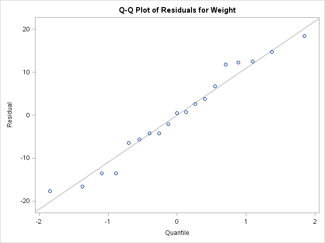

```sas
PROC REG DATA=sashelp.class PLOTS(ONLY) = QQPLOT;
    MODEL Weight = Height;
RUN;
```